# Frame editor

- Visual Python: Data Analysis > Frame
1. Drop - 컬럼 및 행 삭제
2. Rename - 컬럼 이름 변경
3. One-Hot Encoding
4. set_index, reset_index - 인덱스 설정
5. Replace - 데이터 수정
6. As Type - 타입 변경
7. Add Column - 컬럼 및 행 추가

## Import Packages

- Visual Python: Data Analysis > Import

```python
import numpy as np
import pandas as pd
import matplotlib.pyplot as plt
%matplotlib inline
import seaborn as sns
```

## Read data

- Visual Python: Data Analysis > File

```python
# Visual Python: Data Analysis > File
df_economics = pd.read_csv('./data/economics.csv')
df_economics
```

|  | date | pce | pop | psavert | uempmed | unemploy |
| --- | --- | --- | --- | --- | --- | --- |
| 0 | 1967-07-01 | 506.7 | 198712.000 | 12.6 | 4.5 | 2944 |
| 1 | 1967-08-01 | 509.8 | 198911.000 | 12.6 | 4.7 | 2945 |
| 2 | 1967-09-01 | 515.6 | 199113.000 | 11.9 | 4.6 | 2958 |
| 3 | 1967-10-01 | 512.2 | 199311.000 | 12.9 | 4.9 | 3143 |
| 4 | 1967-11-01 | 517.4 | 199498.000 | 12.8 | 4.7 | 3066 |
| ... | ... | ... | ... | ... | ... | ... |
| 569 | 2014-12-01 | 12062.0 | 319746.157 | 7.6 | 12.9 | 8717 |
| 570 | 2015-01-01 | 12046.0 | 319928.646 | 7.7 | 13.2 | 8903 |
| 571 | 2015-02-01 | 12082.4 | 320074.511 | 7.9 | 12.9 | 8610 |
| 572 | 2015-03-01 | 12158.3 | 320230.786 | 7.4 | 12.0 | 8504 |
| 573 | 2015-04-01 | 12193.8 | 320402.295 | 7.6 | 11.5 | 8526 |

574 rows × 6 columns

```python
# Visual Python: Data Analysis > File
df_iris = pd.read_csv('./data/iris.csv')
df_iris
```

|  | sepal_length | sepal_width | petal_length | petal_width | variety |
| --- | --- | --- | --- | --- | --- |
| 0 | 5.1 | 3.5 | 1.4 | 0.2 | Setosa |
| 1 | 4.9 | 3.0 | 1.4 | 0.2 | Setosa |
| 2 | 4.7 | 3.2 | 1.3 | 0.2 | Setosa |
| 3 | 4.6 | 3.1 | 1.5 | 0.2 | Setosa |
| 4 | 5.0 | 3.6 | 1.4 | 0.2 | Setosa |
| ... | ... | ... | ... | ... | ... |
| 145 | 6.7 | 3.0 | 5.2 | 2.3 | Virginica |
| 146 | 6.3 | 2.5 | 5.0 | 1.9 | Virginica |
| 147 | 6.5 | 3.0 | 5.2 | 2.0 | Virginica |
| 148 | 6.2 | 3.4 | 5.4 | 2.3 | Virginica |
| 149 | 5.9 | 3.0 | 5.1 | 1.8 | Virginica |

150 rows × 5 columns

## 1. Edit

## 1.1. Add Column - 컬럼 추가

### 1.1.1. Add Column - Calculation

```python
# Visual Python: Data Analysis > Frame
vp_df = df_iris.copy()
vp_df['col_sum'] = vp_df['sepal_length'] + vp_df['sepal_width']
vp_df
```

|  | sepal_length | sepal_width | petal_length | petal_width | variety | col_sum |
| --- | --- | --- | --- | --- | --- | --- |
| 0 | 5.1 | 3.5 | 1.4 | 0.2 | Setosa | 8.6 |
| 1 | 4.9 | 3.0 | 1.4 | 0.2 | Setosa | 7.9 |
| 2 | 4.7 | 3.2 | 1.3 | 0.2 | Setosa | 7.9 |
| 3 | 4.6 | 3.1 | 1.5 | 0.2 | Setosa | 7.7 |
| 4 | 5.0 | 3.6 | 1.4 | 0.2 | Setosa | 8.6 |
| ... | ... | ... | ... | ... | ... | ... |
| 145 | 6.7 | 3.0 | 5.2 | 2.3 | Virginica | 9.7 |
| 146 | 6.3 | 2.5 | 5.0 | 1.9 | Virginica | 8.8 |
| 147 | 6.5 | 3.0 | 5.2 | 2.0 | Virginica | 9.5 |
| 148 | 6.2 | 3.4 | 5.4 | 2.3 | Virginica | 9.6 |
| 149 | 5.9 | 3.0 | 5.1 | 1.8 | Virginica | 8.9 |

150 rows × 6 columns

### 1.1.2. Add Column - Statistics

```python
# Visual Python: Data Analysis > Frame
vp_df = df_iris.copy()
vp_df['sepal_mean'] = vp_df[['sepal_length','sepal_width']].apply(lambda x: x.mean(numeric_only=True), axis=1)
vp_df
```

|  | sepal_length | sepal_width | petal_length | petal_width | variety | sepal_mean |
| --- | --- | --- | --- | --- | --- | --- |
| 0 | 5.1 | 3.5 | 1.4 | 0.2 | Setosa | 4.30 |
| 1 | 4.9 | 3.0 | 1.4 | 0.2 | Setosa | 3.95 |
| 2 | 4.7 | 3.2 | 1.3 | 0.2 | Setosa | 3.95 |
| 3 | 4.6 | 3.1 | 1.5 | 0.2 | Setosa | 3.85 |
| 4 | 5.0 | 3.6 | 1.4 | 0.2 | Setosa | 4.30 |
| ... | ... | ... | ... | ... | ... | ... |
| 145 | 6.7 | 3.0 | 5.2 | 2.3 | Virginica | 4.85 |
| 146 | 6.3 | 2.5 | 5.0 | 1.9 | Virginica | 4.40 |
| 147 | 6.5 | 3.0 | 5.2 | 2.0 | Virginica | 4.75 |
| 148 | 6.2 | 3.4 | 5.4 | 2.3 | Virginica | 4.80 |
| 149 | 5.9 | 3.0 | 5.1 | 1.8 | Virginica | 4.45 |

150 rows × 6 columns

### 1.1.3. Add Column - Replace

```python
# Visual Python: Data Analysis > Frame
vp_df = df_iris.copy()
vp_df['variety_rep'] = vp_df[['variety']].replace({'Setosa': 'a', 'Versicolor': 'b', 'Virginica': 'c'})
vp_df
```

|  | sepal_length | sepal_width | petal_length | petal_width | variety | variety_rep |
| --- | --- | --- | --- | --- | --- | --- |
| 0 | 5.1 | 3.5 | 1.4 | 0.2 | Setosa | a |
| 1 | 4.9 | 3.0 | 1.4 | 0.2 | Setosa | a |
| 2 | 4.7 | 3.2 | 1.3 | 0.2 | Setosa | a |
| 3 | 4.6 | 3.1 | 1.5 | 0.2 | Setosa | a |
| 4 | 5.0 | 3.6 | 1.4 | 0.2 | Setosa | a |
| ... | ... | ... | ... | ... | ... | ... |
| 145 | 6.7 | 3.0 | 5.2 | 2.3 | Virginica | c |
| 146 | 6.3 | 2.5 | 5.0 | 1.9 | Virginica | c |
| 147 | 6.5 | 3.0 | 5.2 | 2.0 | Virginica | c |
| 148 | 6.2 | 3.4 | 5.4 | 2.3 | Virginica | c |
| 149 | 5.9 | 3.0 | 5.1 | 1.8 | Virginica | c |

150 rows × 6 columns

### 1.1.4. Add Column - Condition

```python
# Visual Python: Data Analysis > Frame
vp_df = df_iris.copy()
vp_df.loc[(vp_df['sepal_length'] > 5), 'sep_cond'] = 'over 5'
vp_df
```

|  | sepal_length | sepal_width | petal_length | petal_width | variety | sep_cond |
| --- | --- | --- | --- | --- | --- | --- |
| 0 | 5.1 | 3.5 | 1.4 | 0.2 | Setosa | over 5 |
| 1 | 4.9 | 3.0 | 1.4 | 0.2 | Setosa | NaN |
| 2 | 4.7 | 3.2 | 1.3 | 0.2 | Setosa | NaN |
| 3 | 4.6 | 3.1 | 1.5 | 0.2 | Setosa | NaN |
| 4 | 5.0 | 3.6 | 1.4 | 0.2 | Setosa | NaN |
| ... | ... | ... | ... | ... | ... | ... |
| 145 | 6.7 | 3.0 | 5.2 | 2.3 | Virginica | over 5 |
| 146 | 6.3 | 2.5 | 5.0 | 1.9 | Virginica | over 5 |
| 147 | 6.5 | 3.0 | 5.2 | 2.0 | Virginica | over 5 |
| 148 | 6.2 | 3.4 | 5.4 | 2.3 | Virginica | over 5 |
| 149 | 5.9 | 3.0 | 5.1 | 1.8 | Virginica | over 5 |

150 rows × 6 columns

### 1.1.5. Add Column - Apply

```python
# Visual Python: Data Analysis > Frame
vp_df = df_iris.copy()
vp_df['sep_cond'] = vp_df['sepal_length'].apply(lambda x: 'over 5' if (x > 5) else 'under 5' if (x <= 5) else np.nan)
vp_df
```

|  | sepal_length | sepal_width | petal_length | petal_width | variety | sep_cond |
| --- | --- | --- | --- | --- | --- | --- |
| 0 | 5.1 | 3.5 | 1.4 | 0.2 | Setosa | over 5 |
| 1 | 4.9 | 3.0 | 1.4 | 0.2 | Setosa | under 5 |
| 2 | 4.7 | 3.2 | 1.3 | 0.2 | Setosa | under 5 |
| 3 | 4.6 | 3.1 | 1.5 | 0.2 | Setosa | under 5 |
| 4 | 5.0 | 3.6 | 1.4 | 0.2 | Setosa | under 5 |
| ... | ... | ... | ... | ... | ... | ... |
| 145 | 6.7 | 3.0 | 5.2 | 2.3 | Virginica | over 5 |
| 146 | 6.3 | 2.5 | 5.0 | 1.9 | Virginica | over 5 |
| 147 | 6.5 | 3.0 | 5.2 | 2.0 | Virginica | over 5 |
| 148 | 6.2 | 3.4 | 5.4 | 2.3 | Virginica | over 5 |
| 149 | 5.9 | 3.0 | 5.1 | 1.8 | Virginica | over 5 |

150 rows × 6 columns

## 1.2. Delete - 컬럼 및 행 삭제

```python
# Visual Python: Data Analysis > Frame
vp_df = df_iris.copy()
vp_df.drop(['petal_length','petal_width'], axis=1, inplace=True)
vp_df
```

|  | sepal_length | sepal_width | variety |
| --- | --- | --- | --- |
| 0 | 5.1 | 3.5 | Setosa |
| 1 | 4.9 | 3.0 | Setosa |
| 2 | 4.7 | 3.2 | Setosa |
| 3 | 4.6 | 3.1 | Setosa |
| 4 | 5.0 | 3.6 | Setosa |
| ... | ... | ... | ... |
| 145 | 6.7 | 3.0 | Virginica |
| 146 | 6.3 | 2.5 | Virginica |
| 147 | 6.5 | 3.0 | Virginica |
| 148 | 6.2 | 3.4 | Virginica |
| 149 | 5.9 | 3.0 | Virginica |

150 rows × 3 columns

## 1.3. Rename - 컬럼 이름 변경

```python
# Visual Python: Data Analysis > Frame
vp_df = df_iris.copy()
vp_df.rename(columns={'sepal_length': 'sl', 'sepal_width': 'sw', 'petal_length': 'pl', 'petal_width': 'pw', 'variety': 'v'}, inplace=True)
vp_df
```

|  | sl | sw | pl | pw | v |
| --- | --- | --- | --- | --- | --- |
| 0 | 5.1 | 3.5 | 1.4 | 0.2 | Setosa |
| 1 | 4.9 | 3.0 | 1.4 | 0.2 | Setosa |
| 2 | 4.7 | 3.2 | 1.3 | 0.2 | Setosa |
| 3 | 4.6 | 3.1 | 1.5 | 0.2 | Setosa |
| 4 | 5.0 | 3.6 | 1.4 | 0.2 | Setosa |
| ... | ... | ... | ... | ... | ... |
| 145 | 6.7 | 3.0 | 5.2 | 2.3 | Virginica |
| 146 | 6.3 | 2.5 | 5.0 | 1.9 | Virginica |
| 147 | 6.5 | 3.0 | 5.2 | 2.0 | Virginica |
| 148 | 6.2 | 3.4 | 5.4 | 2.3 | Virginica |
| 149 | 5.9 | 3.0 | 5.1 | 1.8 | Virginica |

150 rows × 5 columns

## 1.4. As type - 데이터 타입 변경

```python
# Visual Python: Data Analysis > Frame
vp_df = df_iris.copy()
vp_df = vp_df.astype({'sepal_length': 'int64', 'variety': 'category'})
vp_df
```

|  | sepal_length | sepal_width | petal_length | petal_width | variety |
| --- | --- | --- | --- | --- | --- |
| 0 | 5 | 3.5 | 1.4 | 0.2 | Setosa |
| 1 | 4 | 3.0 | 1.4 | 0.2 | Setosa |
| 2 | 4 | 3.2 | 1.3 | 0.2 | Setosa |
| 3 | 4 | 3.1 | 1.5 | 0.2 | Setosa |
| 4 | 5 | 3.6 | 1.4 | 0.2 | Setosa |
| ... | ... | ... | ... | ... | ... |
| 145 | 6 | 3.0 | 5.2 | 2.3 | Virginica |
| 146 | 6 | 2.5 | 5.0 | 1.9 | Virginica |
| 147 | 6 | 3.0 | 5.2 | 2.0 | Virginica |
| 148 | 6 | 3.4 | 5.4 | 2.3 | Virginica |
| 149 | 5 | 3.0 | 5.1 | 1.8 | Virginica |

150 rows × 5 columns

```python
# Visual Python: Data Analysis > Frame
vp_df = df_economics.copy()
vp_df = vp_df.astype({'date': 'datetime64[ns]'})
vp_df
```

|  | date | pce | pop | psavert | uempmed | unemploy |
| --- | --- | --- | --- | --- | --- | --- |
| 0 | 1967-07-01 | 506.7 | 198712.000 | 12.6 | 4.5 | 2944 |
| 1 | 1967-08-01 | 509.8 | 198911.000 | 12.6 | 4.7 | 2945 |
| 2 | 1967-09-01 | 515.6 | 199113.000 | 11.9 | 4.6 | 2958 |
| 3 | 1967-10-01 | 512.2 | 199311.000 | 12.9 | 4.9 | 3143 |
| 4 | 1967-11-01 | 517.4 | 199498.000 | 12.8 | 4.7 | 3066 |
| ... | ... | ... | ... | ... | ... | ... |
| 569 | 2014-12-01 | 12062.0 | 319746.157 | 7.6 | 12.9 | 8717 |
| 570 | 2015-01-01 | 12046.0 | 319928.646 | 7.7 | 13.2 | 8903 |
| 571 | 2015-02-01 | 12082.4 | 320074.511 | 7.9 | 12.9 | 8610 |
| 572 | 2015-03-01 | 12158.3 | 320230.786 | 7.4 | 12.0 | 8504 |
| 573 | 2015-04-01 | 12193.8 | 320402.295 | 7.6 | 11.5 | 8526 |

574 rows × 6 columns

## 1.5. To Datetime - 날짜 형식 컬럼의 타입 변경 및 부가적인 컬럼 생성

```python
# Visual Python: Data Analysis > Frame
vp_df = df_economics.copy()
vp_df['date'] = pd.to_datetime(vp_df['date'])
vp_df['year'] = vp_df['date'].dt.year
vp_df['month'] = vp_df['date'].dt.month
vp_df['day'] = vp_df['date'].dt.day
vp_df
```

|  | date | pce | pop | psavert | uempmed | unemploy | year | month | day |
| --- | --- | --- | --- | --- | --- | --- | --- | --- | --- |
| 0 | 1967-07-01 | 506.7 | 198712.000 | 12.6 | 4.5 | 2944 | 1967 | 7 | 1 |
| 1 | 1967-08-01 | 509.8 | 198911.000 | 12.6 | 4.7 | 2945 | 1967 | 8 | 1 |
| 2 | 1967-09-01 | 515.6 | 199113.000 | 11.9 | 4.6 | 2958 | 1967 | 9 | 1 |
| 3 | 1967-10-01 | 512.2 | 199311.000 | 12.9 | 4.9 | 3143 | 1967 | 10 | 1 |
| 4 | 1967-11-01 | 517.4 | 199498.000 | 12.8 | 4.7 | 3066 | 1967 | 11 | 1 |
| ... | ... | ... | ... | ... | ... | ... | ... | ... | ... |
| 569 | 2014-12-01 | 12062.0 | 319746.157 | 7.6 | 12.9 | 8717 | 2014 | 12 | 1 |
| 570 | 2015-01-01 | 12046.0 | 319928.646 | 7.7 | 13.2 | 8903 | 2015 | 1 | 1 |
| 571 | 2015-02-01 | 12082.4 | 320074.511 | 7.9 | 12.9 | 8610 | 2015 | 2 | 1 |
| 572 | 2015-03-01 | 12158.3 | 320230.786 | 7.4 | 12.0 | 8504 | 2015 | 3 | 1 |
| 573 | 2015-04-01 | 12193.8 | 320402.295 | 7.6 | 11.5 | 8526 | 2015 | 4 | 1 |

574 rows × 9 columns

## 1.6. Replace - 데이터 대체

```python
# Visual Python: Data Analysis > Frame
vp_df = df_iris.copy()
vp_df.loc[:, 'sepal_length'] = 1
vp_df
```

|  | sepal_length | sepal_width | petal_length | petal_width | variety |
| --- | --- | --- | --- | --- | --- |
| 0 | 1 | 3.5 | 1.4 | 0.2 | Setosa |
| 1 | 1 | 3.0 | 1.4 | 0.2 | Setosa |
| 2 | 1 | 3.2 | 1.3 | 0.2 | Setosa |
| 3 | 1 | 3.1 | 1.5 | 0.2 | Setosa |
| 4 | 1 | 3.6 | 1.4 | 0.2 | Setosa |
| ... | ... | ... | ... | ... | ... |
| 145 | 1 | 3.0 | 5.2 | 2.3 | Virginica |
| 146 | 1 | 2.5 | 5.0 | 1.9 | Virginica |
| 147 | 1 | 3.0 | 5.2 | 2.0 | Virginica |
| 148 | 1 | 3.4 | 5.4 | 2.3 | Virginica |
| 149 | 1 | 3.0 | 5.1 | 1.8 | Virginica |

150 rows × 5 columns

## 1.7. Discretize - 데이터 구간 분할

```python
# Visual Python: Data Analysis > Frame
vp_df = df_iris.copy()
vp_df['sl_cut'] = pd.cut(vp_df['sepal_length'], 5, labels=['a', 'b', 'c', 'd', 'e'])
vp_df
```

|  | sepal_length | sepal_width | petal_length | petal_width | variety | sl_cut |
| --- | --- | --- | --- | --- | --- | --- |
| 0 | 5.1 | 3.5 | 1.4 | 0.2 | Setosa | b |
| 1 | 4.9 | 3.0 | 1.4 | 0.2 | Setosa | a |
| 2 | 4.7 | 3.2 | 1.3 | 0.2 | Setosa | a |
| 3 | 4.6 | 3.1 | 1.5 | 0.2 | Setosa | a |
| 4 | 5.0 | 3.6 | 1.4 | 0.2 | Setosa | a |
| ... | ... | ... | ... | ... | ... | ... |
| 145 | 6.7 | 3.0 | 5.2 | 2.3 | Virginica | d |
| 146 | 6.3 | 2.5 | 5.0 | 1.9 | Virginica | c |
| 147 | 6.5 | 3.0 | 5.2 | 2.0 | Virginica | d |
| 148 | 6.2 | 3.4 | 5.4 | 2.3 | Virginica | c |
| 149 | 5.9 | 3.0 | 5.1 | 1.8 | Virginica | c |

150 rows × 6 columns

# 2. Transform

## 2.1. set_index, reset_index - 인덱스 설정

```python
# Visual Python: Data Analysis > Frame
df1 = df_iris.copy()
df1.set_index(['variety'], inplace=True)
df1
```

| variety | sepal_length | sepal_width | petal_length | petal_width |
| --- | --- | --- | --- | --- |
| Setosa | 5.1 | 3.5 | 1.4 | 0.2 |
| Setosa | 4.9 | 3.0 | 1.4 | 0.2 |
| Setosa | 4.7 | 3.2 | 1.3 | 0.2 |
| Setosa | 4.6 | 3.1 | 1.5 | 0.2 |
| Setosa | 5.0 | 3.6 | 1.4 | 0.2 |
| ... | ... | ... | ... | ... |
| Virginica | 6.7 | 3.0 | 5.2 | 2.3 |
| Virginica | 6.3 | 2.5 | 5.0 | 1.9 |
| Virginica | 6.5 | 3.0 | 5.2 | 2.0 |
| Virginica | 6.2 | 3.4 | 5.4 | 2.3 |
| Virginica | 5.9 | 3.0 | 5.1 | 1.8 |

150 rows × 4 columns

```python
# Visual Python: Data Analysis > Frame
vp_df = df1.copy()
vp_df.reset_index(inplace=True)
vp_df
```

|  | variety | sepal_length | sepal_width | petal_length | petal_width |
| --- | --- | --- | --- | --- | --- |
| 0 | Setosa | 5.1 | 3.5 | 1.4 | 0.2 |
| 1 | Setosa | 4.9 | 3.0 | 1.4 | 0.2 |
| 2 | Setosa | 4.7 | 3.2 | 1.3 | 0.2 |
| 3 | Setosa | 4.6 | 3.1 | 1.5 | 0.2 |
| 4 | Setosa | 5.0 | 3.6 | 1.4 | 0.2 |
| ... | ... | ... | ... | ... | ... |
| 145 | Virginica | 6.7 | 3.0 | 5.2 | 2.3 |
| 146 | Virginica | 6.3 | 2.5 | 5.0 | 1.9 |
| 147 | Virginica | 6.5 | 3.0 | 5.2 | 2.0 |
| 148 | Virginica | 6.2 | 3.4 | 5.4 | 2.3 |
| 149 | Virginica | 5.9 | 3.0 | 5.1 | 1.8 |

150 rows × 5 columns

## 2.2. Data Shift - 데이터 옮기기

```python
# Visual Python: Data Analysis > Frame
vp_df = df_iris.copy()
vp_df['petal_length'] = vp_df['petal_length'].shift(1, fill_value=0)
vp_df
```

|  | sepal_length | sepal_width | petal_length | petal_width | variety |
| --- | --- | --- | --- | --- | --- |
| 0 | 5.1 | 3.5 | 0.0 | 0.2 | Setosa |
| 1 | 4.9 | 3.0 | 1.4 | 0.2 | Setosa |
| 2 | 4.7 | 3.2 | 1.4 | 0.2 | Setosa |
| 3 | 4.6 | 3.1 | 1.3 | 0.2 | Setosa |
| 4 | 5.0 | 3.6 | 1.5 | 0.2 | Setosa |
| ... | ... | ... | ... | ... | ... |
| 145 | 6.7 | 3.0 | 5.7 | 2.3 | Virginica |
| 146 | 6.3 | 2.5 | 5.2 | 1.9 | Virginica |
| 147 | 6.5 | 3.0 | 5.0 | 2.0 | Virginica |
| 148 | 6.2 | 3.4 | 5.2 | 2.3 | Virginica |
| 149 | 5.9 | 3.0 | 5.4 | 1.8 | Virginica |

150 rows × 5 columns

# 3. Sort

## 3.1. Sort index & Sort values - 데이터 정렬하기

```python
# Visual Python: Data Analysis > Frame
vp_df = df_iris.copy()
vp_df.sort_index(axis=0, ascending=True, inplace=True)
vp_df.sort_values(by='sepal_length', ascending=True, inplace=True)
vp_df
```

|  | sepal_length | sepal_width | petal_length | petal_width | variety |
| --- | --- | --- | --- | --- | --- |
| 13 | 4.3 | 3.0 | 1.1 | 0.1 | Setosa |
| 42 | 4.4 | 3.2 | 1.3 | 0.2 | Setosa |
| 38 | 4.4 | 3.0 | 1.3 | 0.2 | Setosa |
| 8 | 4.4 | 2.9 | 1.4 | 0.2 | Setosa |
| 41 | 4.5 | 2.3 | 1.3 | 0.3 | Setosa |
| ... | ... | ... | ... | ... | ... |
| 122 | 7.7 | 2.8 | 6.7 | 2.0 | Virginica |
| 118 | 7.7 | 2.6 | 6.9 | 2.3 | Virginica |
| 117 | 7.7 | 3.8 | 6.7 | 2.2 | Virginica |
| 135 | 7.7 | 3.0 | 6.1 | 2.3 | Virginica |
| 131 | 7.9 | 3.8 | 6.4 | 2.0 | Virginica |

150 rows × 5 columns

# 4. Encoding

## 4.1. Label Encoding

```python
# Visual Python: Data Analysis > Frame
vp_df = df_iris.copy()
vp_df['variety_label'] = pd.Categorical(vp_df['variety']).codes
vp_df
```

|  | sepal_length | sepal_width | petal_length | petal_width | variety | variety_label |
| --- | --- | --- | --- | --- | --- | --- |
| 0 | 5.1 | 3.5 | 1.4 | 0.2 | Setosa | 0 |
| 1 | 4.9 | 3.0 | 1.4 | 0.2 | Setosa | 0 |
| 2 | 4.7 | 3.2 | 1.3 | 0.2 | Setosa | 0 |
| 3 | 4.6 | 3.1 | 1.5 | 0.2 | Setosa | 0 |
| 4 | 5.0 | 3.6 | 1.4 | 0.2 | Setosa | 0 |
| ... | ... | ... | ... | ... | ... | ... |
| 145 | 6.7 | 3.0 | 5.2 | 2.3 | Virginica | 2 |
| 146 | 6.3 | 2.5 | 5.0 | 1.9 | Virginica | 2 |
| 147 | 6.5 | 3.0 | 5.2 | 2.0 | Virginica | 2 |
| 148 | 6.2 | 3.4 | 5.4 | 2.3 | Virginica | 2 |
| 149 | 5.9 | 3.0 | 5.1 | 1.8 | Virginica | 2 |

150 rows × 6 columns

## 4.2. One-hot Encoding

```python
# Visual Python: Data Analysis > Frame
vp_df = df_iris.copy()
vp_df = pd.get_dummies(data=vp_df, columns=['variety'])
vp_df
```

|  | sepal_length | sepal_width | petal_length | petal_width | variety_Setosa | variety_Versicolor | variety_Virginica |
| --- | --- | --- | --- | --- | --- | --- | --- |
| 0 | 5.1 | 3.5 | 1.4 | 0.2 | 1 | 0 | 0 |
| 1 | 4.9 | 3.0 | 1.4 | 0.2 | 1 | 0 | 0 |
| 2 | 4.7 | 3.2 | 1.3 | 0.2 | 1 | 0 | 0 |
| 3 | 4.6 | 3.1 | 1.5 | 0.2 | 1 | 0 | 0 |
| 4 | 5.0 | 3.6 | 1.4 | 0.2 | 1 | 0 | 0 |
| ... | ... | ... | ... | ... | ... | ... | ... |
| 145 | 6.7 | 3.0 | 5.2 | 2.3 | 0 | 0 | 1 |
| 146 | 6.3 | 2.5 | 5.0 | 1.9 | 0 | 0 | 1 |
| 147 | 6.5 | 3.0 | 5.2 | 2.0 | 0 | 0 | 1 |
| 148 | 6.2 | 3.4 | 5.4 | 2.3 | 0 | 0 | 1 |
| 149 | 5.9 | 3.0 | 5.1 | 1.8 | 0 | 0 | 1 |

150 rows × 7 columns

# 5. Data cleaning

- Null data 만들기

```python
# Visual Python: Data Analysis > Frame
df1 = df_iris.copy()
df1['petal_length'] = df1['petal_length'].shift(3)
df1
```

|  | sepal_length | sepal_width | petal_length | petal_width | variety |
| --- | --- | --- | --- | --- | --- |
| 0 | 5.1 | 3.5 | NaN | 0.2 | Setosa |
| 1 | 4.9 | 3.0 | NaN | 0.2 | Setosa |
| 2 | 4.7 | 3.2 | NaN | 0.2 | Setosa |
| 3 | 4.6 | 3.1 | 1.4 | 0.2 | Setosa |
| 4 | 5.0 | 3.6 | 1.4 | 0.2 | Setosa |
| ... | ... | ... | ... | ... | ... |
| 145 | 6.7 | 3.0 | 5.1 | 2.3 | Virginica |
| 146 | 6.3 | 2.5 | 5.9 | 1.9 | Virginica |
| 147 | 6.5 | 3.0 | 5.7 | 2.0 | Virginica |
| 148 | 6.2 | 3.4 | 5.2 | 2.3 | Virginica |
| 149 | 5.9 | 3.0 | 5.0 | 1.8 | Virginica |

150 rows × 5 columns

```python
# Visual Python: Data Analysis > Data Info
pd.DataFrame({'Null Count': df1.isnull().sum(), 'Non-Null Count': df1.notnull().sum()})
```

|  | Null Count | Non-Null Count |
| --- | --- | --- |
| sepal_length | 0 | 150 |
| sepal_width | 0 | 150 |
| petal_length | 3 | 147 |
| petal_width | 0 | 150 |
| variety | 0 | 150 |

## 5.1. Fill NA - 결측치 채우기

```python
# Visual Python: Data Analysis > Frame
vp_df = df1.copy()
vp_df['petal_length'] = vp_df['petal_length'].fillna(0)
vp_df
```

|  | sepal_length | sepal_width | petal_length | petal_width | variety |
| --- | --- | --- | --- | --- | --- |
| 0 | 5.1 | 3.5 | 0.0 | 0.2 | Setosa |
| 1 | 4.9 | 3.0 | 0.0 | 0.2 | Setosa |
| 2 | 4.7 | 3.2 | 0.0 | 0.2 | Setosa |
| 3 | 4.6 | 3.1 | 1.4 | 0.2 | Setosa |
| 4 | 5.0 | 3.6 | 1.4 | 0.2 | Setosa |
| ... | ... | ... | ... | ... | ... |
| 145 | 6.7 | 3.0 | 5.1 | 2.3 | Virginica |
| 146 | 6.3 | 2.5 | 5.9 | 1.9 | Virginica |
| 147 | 6.5 | 3.0 | 5.7 | 2.0 | Virginica |
| 148 | 6.2 | 3.4 | 5.2 | 2.3 | Virginica |
| 149 | 5.9 | 3.0 | 5.0 | 1.8 | Virginica |

150 rows × 5 columns

## 5.2. Drop NA - 결측치 제거

```python
# Visual Python: Data Analysis > Frame
vp_df = df1.copy()
vp_df.dropna(axis=0, subset=['petal_length'], how='all', inplace=True)
vp_df
```

|  | sepal_length | sepal_width | petal_length | petal_width | variety |
| --- | --- | --- | --- | --- | --- |
| 3 | 4.6 | 3.1 | 1.4 | 0.2 | Setosa |
| 4 | 5.0 | 3.6 | 1.4 | 0.2 | Setosa |
| 5 | 5.4 | 3.9 | 1.3 | 0.4 | Setosa |
| 6 | 4.6 | 3.4 | 1.5 | 0.3 | Setosa |
| 7 | 5.0 | 3.4 | 1.4 | 0.2 | Setosa |
| ... | ... | ... | ... | ... | ... |
| 145 | 6.7 | 3.0 | 5.1 | 2.3 | Virginica |
| 146 | 6.3 | 2.5 | 5.9 | 1.9 | Virginica |
| 147 | 6.5 | 3.0 | 5.7 | 2.0 | Virginica |
| 148 | 6.2 | 3.4 | 5.2 | 2.3 | Virginica |
| 149 | 5.9 | 3.0 | 5.0 | 1.8 | Virginica |

147 rows × 5 columns

## 5.3. Fill Outlier - 이상치 채우기

### 5.3.1. Before fill outlier

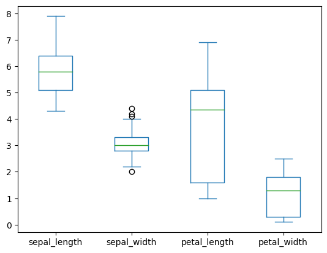

```python
# Visual Python: Data Analysis > Data Info
df_iris.plot(kind='box')
plt.show()
```

### 5.3.2. Fill outlier

```python
# Visual Python: Data Analysis > Frame
def vp_fill_outlier(df, col_lst, fill_type='iqr', fill_value_lst=[], weight=1.5):
    dfr = df.copy()
    for idx, col in enumerate(col_lst):
        sr = dfr[col]
        q25 = np.percentile(sr.values, 25)
        q75 = np.percentile(sr.values, 75)
        iqr   = q75 - q25
        iqr_w = iqr * weight
        val_l = q25 - iqr_w
        val_h = q75 + iqr_w
        if fill_type == 'mean':
            f_val = sr[~((sr < val_l) | (sr > val_h))].mean()
        elif fill_type == 'median':
            f_val = sr[~((sr < val_l) | (sr > val_h))].median()
        elif fill_type == 'value':
            f_val = fill_value_lst[idx]
        elif fill_type == 'NA':
            f_val = np.nan
        if fill_type == 'iqr':
            dfr.loc[(sr < val_l), col] = val_l
            dfr.loc[(sr > val_h), col] = val_h
        else:
            dfr.loc[(sr < val_l) | (sr > val_h), col] = f_val
    return dfr
```

```python
# Visual Python: Data Analysis > Frame
vp_df = df_iris.copy()
vp_df = vp_fill_outlier(vp_df, ['sepal_width'], fill_type='iqr')
vp_df
```

|  | sepal_length | sepal_width | petal_length | petal_width | variety |
| --- | --- | --- | --- | --- | --- |
| 0 | 5.1 | 3.5 | 1.4 | 0.2 | Setosa |
| 1 | 4.9 | 3.0 | 1.4 | 0.2 | Setosa |
| 2 | 4.7 | 3.2 | 1.3 | 0.2 | Setosa |
| 3 | 4.6 | 3.1 | 1.5 | 0.2 | Setosa |
| 4 | 5.0 | 3.6 | 1.4 | 0.2 | Setosa |
| ... | ... | ... | ... | ... | ... |
| 145 | 6.7 | 3.0 | 5.2 | 2.3 | Virginica |
| 146 | 6.3 | 2.5 | 5.0 | 1.9 | Virginica |
| 147 | 6.5 | 3.0 | 5.2 | 2.0 | Virginica |
| 148 | 6.2 | 3.4 | 5.4 | 2.3 | Virginica |
| 149 | 5.9 | 3.0 | 5.1 | 1.8 | Virginica |

150 rows × 5 columns

### 5.3.3. After fill outlier

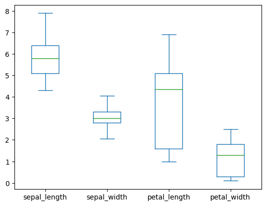

```python
# Visual Python: Data Analysis > Data Info
vp_df.plot(kind='box')
plt.show()
```

## 5.4. Drop outlier - 이상치 제거하기

### 5.4.1. Drop outlier

```python
# Visual Python: Data Analysis > Frame
def vp_drop_outlier(df, col_lst, weight=1.5):
    dfr = df.copy()
    outlier_index_lst = []
    for idx, col in enumerate(col_lst):
        sr = dfr[col]
        q25 = np.percentile(sr.values, 25)
        q75 = np.percentile(sr.values, 75)
        iqr   = q75 - q25
        iqr_w = iqr * weight
        val_l = q25 - iqr_w
        val_h = q75 + iqr_w
        outlier_index_lst += sr[(sr < val_l) | (sr > val_h)].index.to_list()
    outlier_index_lst = list(set(outlier_index_lst))
    dfr.drop(outlier_index_lst, inplace=True)
    return dfr
```

```python
# Visual Python: Data Analysis > Frame
vp_df = df_iris.copy()
vp_df = vp_drop_outlier(vp_df, ['sepal_width'])
vp_df
```

|  | sepal_length | sepal_width | petal_length | petal_width | variety |
| --- | --- | --- | --- | --- | --- |
| 0 | 5.1 | 3.5 | 1.4 | 0.2 | Setosa |
| 1 | 4.9 | 3.0 | 1.4 | 0.2 | Setosa |
| 2 | 4.7 | 3.2 | 1.3 | 0.2 | Setosa |
| 3 | 4.6 | 3.1 | 1.5 | 0.2 | Setosa |
| 4 | 5.0 | 3.6 | 1.4 | 0.2 | Setosa |
| ... | ... | ... | ... | ... | ... |
| 145 | 6.7 | 3.0 | 5.2 | 2.3 | Virginica |
| 146 | 6.3 | 2.5 | 5.0 | 1.9 | Virginica |
| 147 | 6.5 | 3.0 | 5.2 | 2.0 | Virginica |
| 148 | 6.2 | 3.4 | 5.4 | 2.3 | Virginica |
| 149 | 5.9 | 3.0 | 5.1 | 1.8 | Virginica |

146 rows × 5 columns

### 5.4.2. After drop outlier

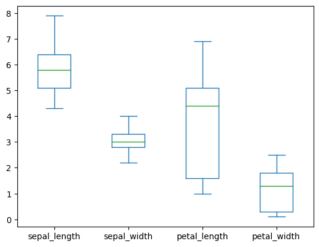

```python
# Visual Python: Data Analysis > Data Info
vp_df.plot(kind='box')
plt.show()
```

## 5.5. Drop duplicates - 중복값 제거

### 5.5.1. Check duplicates

```python
# Visual Python: Data Analysis > Data Info
_duplicated = ([df_iris[['variety']].duplicated().sum()] + [df_iris[['variety']][col].duplicated().sum() for col in df_iris[['variety']].columns])
_duplicated_df = pd.DataFrame({
    'Rows':[len(df_iris[['variety']])]*len(_duplicated),
    'Unique':[len(df_iris[['variety']]) - dups for dups in _duplicated],
    'Duplicated': _duplicated,
    'Duplicated by': ['All columns'] + df_iris[['variety']].columns.to_list()
}, index=['Combination']+df_iris[['variety']].columns.to_list())
_duplicated_df
```

|  | Rows | Unique | Duplicated | Duplicated by |
| --- | --- | --- | --- | --- |
| Combination | 150 | 3 | 147 | All columns |
| variety | 150 | 3 | 147 | variety |

### 5.5.2. Drop duplicates

```python
# Visual Python: Data Analysis > Frame
vp_df = df_iris.copy()
vp_df.drop_duplicates(subset=['variety'], inplace=True)
vp_df
```

|  | sepal_length | sepal_width | petal_length | petal_width | variety |
| --- | --- | --- | --- | --- | --- |
| 0 | 5.1 | 3.5 | 1.4 | 0.2 | Setosa |
| 50 | 7.0 | 3.2 | 4.7 | 1.4 | Versicolor |
| 100 | 6.3 | 3.3 | 6.0 | 2.5 | Virginica |

# [실습] 직접 해보기

# 실습 1. iris 데이터로 복습하기

```python
# Visual Python: Data Analysis > File
df = pd.read_csv('./data/iris.csv')
df
```

|  | sepal_length | sepal_width | petal_length | petal_width | variety |
| --- | --- | --- | --- | --- | --- |
| 0 | 5.1 | 3.5 | 1.4 | 0.2 | Setosa |
| 1 | 4.9 | 3.0 | 1.4 | 0.2 | Setosa |
| 2 | 4.7 | 3.2 | 1.3 | 0.2 | Setosa |
| 3 | 4.6 | 3.1 | 1.5 | 0.2 | Setosa |
| 4 | 5.0 | 3.6 | 1.4 | 0.2 | Setosa |
| ... | ... | ... | ... | ... | ... |
| 145 | 6.7 | 3.0 | 5.2 | 2.3 | Virginica |
| 146 | 6.3 | 2.5 | 5.0 | 1.9 | Virginica |
| 147 | 6.5 | 3.0 | 5.2 | 2.0 | Virginica |
| 148 | 6.2 | 3.4 | 5.4 | 2.3 | Virginica |
| 149 | 5.9 | 3.0 | 5.1 | 1.8 | Virginica |

150 rows × 5 columns

#### 1 Iris 데이터(df)의 컬럼 'sepal_width' 와 'petal_length'를 삭제하세요.

```python
df1 = df.copy()
df1.drop(['sepal_width','petal_length'], axis=1, inplace=True)
df1
```

|  | sepal_length | petal_width | variety |
| --- | --- | --- | --- |
| 0 | 5.1 | 0.2 | Setosa |
| 1 | 4.9 | 0.2 | Setosa |
| 2 | 4.7 | 0.2 | Setosa |
| 3 | 4.6 | 0.2 | Setosa |
| 4 | 5.0 | 0.2 | Setosa |
| ... | ... | ... | ... |
| 145 | 6.7 | 2.3 | Virginica |
| 146 | 6.3 | 1.9 | Virginica |
| 147 | 6.5 | 2.0 | Virginica |
| 148 | 6.2 | 2.3 | Virginica |
| 149 | 5.9 | 1.8 | Virginica |

150 rows × 3 columns

#### 2 Iris 데이터(df)의 컬럼 이름을 다음과 같이 변경하고 df_kor에 저장하세요.

- '꽃받침길이', '꽃받침너비', '꽃잎길이', '꽃잎너비', '품종'

```python
df_kor = df.copy()
df_kor.rename(columns={'sepal_length': '꽃받침길이', 'sepal_width': '꽃받침너비', 'petal_length': '꽃잎길이', 'petal_width': '꽃잎너비', 'variety': '품종'}, inplace=True)
df_kor
```

|  | 꽃받침길이 | 꽃받침너비 | 꽃잎길이 | 꽃잎너비 | 품종 |
| --- | --- | --- | --- | --- | --- |
| 0 | 5.1 | 3.5 | 1.4 | 0.2 | Setosa |
| 1 | 4.9 | 3.0 | 1.4 | 0.2 | Setosa |
| 2 | 4.7 | 3.2 | 1.3 | 0.2 | Setosa |
| 3 | 4.6 | 3.1 | 1.5 | 0.2 | Setosa |
| 4 | 5.0 | 3.6 | 1.4 | 0.2 | Setosa |
| ... | ... | ... | ... | ... | ... |
| 145 | 6.7 | 3.0 | 5.2 | 2.3 | Virginica |
| 146 | 6.3 | 2.5 | 5.0 | 1.9 | Virginica |
| 147 | 6.5 | 3.0 | 5.2 | 2.0 | Virginica |
| 148 | 6.2 | 3.4 | 5.4 | 2.3 | Virginica |
| 149 | 5.9 | 3.0 | 5.1 | 1.8 | Virginica |

150 rows × 5 columns

#### 3 위에서 변경한 데이터(df_kor)의 '품종' 컬럼을 One-Hot Encoding으로 변경하세요.

```python
df3 = df_kor.copy()
df3 = pd.get_dummies(data=df3, columns=['품종'])
df3
```

|  | 꽃받침길이 | 꽃받침너비 | 꽃잎길이 | 꽃잎너비 | 품종_Setosa | 품종_Versicolor | 품종_Virginica |
| --- | --- | --- | --- | --- | --- | --- | --- |
| 0 | 5.1 | 3.5 | 1.4 | 0.2 | 1 | 0 | 0 |
| 1 | 4.9 | 3.0 | 1.4 | 0.2 | 1 | 0 | 0 |
| 2 | 4.7 | 3.2 | 1.3 | 0.2 | 1 | 0 | 0 |
| 3 | 4.6 | 3.1 | 1.5 | 0.2 | 1 | 0 | 0 |
| 4 | 5.0 | 3.6 | 1.4 | 0.2 | 1 | 0 | 0 |
| ... | ... | ... | ... | ... | ... | ... | ... |
| 145 | 6.7 | 3.0 | 5.2 | 2.3 | 0 | 0 | 1 |
| 146 | 6.3 | 2.5 | 5.0 | 1.9 | 0 | 0 | 1 |
| 147 | 6.5 | 3.0 | 5.2 | 2.0 | 0 | 0 | 1 |
| 148 | 6.2 | 3.4 | 5.4 | 2.3 | 0 | 0 | 1 |
| 149 | 5.9 | 3.0 | 5.1 | 1.8 | 0 | 0 | 1 |

150 rows × 7 columns

#### 4 df_kor의 컬럼 '꽃받침길이'를 인덱스로 설정하세요.

```python
df4 = df_kor.copy()
df4.set_index(['꽃받침길이'], inplace=True)
df4
```

| 꽃받침길이 | 꽃받침너비 | 꽃잎길이 | 꽃잎너비 | 품종 |
| --- | --- | --- | --- | --- |
| 5.1 | 3.5 | 1.4 | 0.2 | Setosa |
| 4.9 | 3.0 | 1.4 | 0.2 | Setosa |
| 4.7 | 3.2 | 1.3 | 0.2 | Setosa |
| 4.6 | 3.1 | 1.5 | 0.2 | Setosa |
| 5.0 | 3.6 | 1.4 | 0.2 | Setosa |
| ... | ... | ... | ... | ... |
| 6.7 | 3.0 | 5.2 | 2.3 | Virginica |
| 6.3 | 2.5 | 5.0 | 1.9 | Virginica |
| 6.5 | 3.0 | 5.2 | 2.0 | Virginica |
| 6.2 | 3.4 | 5.4 | 2.3 | Virginica |
| 5.9 | 3.0 | 5.1 | 1.8 | Virginica |

150 rows × 4 columns

#### 5 df_kor의 컬럼 '꽃잎길이'값을 10.0으로 설정하세요.

```python
df5 = df_kor.copy()
df5['꽃잎길이'] = 10.0
df5
```

|  | 꽃받침길이 | 꽃받침너비 | 꽃잎길이 | 꽃잎너비 | 품종 |
| --- | --- | --- | --- | --- | --- |
| 0 | 5.1 | 3.5 | 10.0 | 0.2 | Setosa |
| 1 | 4.9 | 3.0 | 10.0 | 0.2 | Setosa |
| 2 | 4.7 | 3.2 | 10.0 | 0.2 | Setosa |
| 3 | 4.6 | 3.1 | 10.0 | 0.2 | Setosa |
| 4 | 5.0 | 3.6 | 10.0 | 0.2 | Setosa |
| ... | ... | ... | ... | ... | ... |
| 145 | 6.7 | 3.0 | 10.0 | 2.3 | Virginica |
| 146 | 6.3 | 2.5 | 10.0 | 1.9 | Virginica |
| 147 | 6.5 | 3.0 | 10.0 | 2.0 | Virginica |
| 148 | 6.2 | 3.4 | 10.0 | 2.3 | Virginica |
| 149 | 5.9 | 3.0 | 10.0 | 1.8 | Virginica |

150 rows × 5 columns

#### 6 df_kor의 컬럼 '꽃잎길이'의 타입을 int64로 설정하세요.

```python
df6 = df_kor.copy()
df6 = df6.astype({'꽃잎길이': 'int64'})
df6
```

|  | 꽃받침길이 | 꽃받침너비 | 꽃잎길이 | 꽃잎너비 | 품종 |
| --- | --- | --- | --- | --- | --- |
| 0 | 5.1 | 3.5 | 1 | 0.2 | Setosa |
| 1 | 4.9 | 3.0 | 1 | 0.2 | Setosa |
| 2 | 4.7 | 3.2 | 1 | 0.2 | Setosa |
| 3 | 4.6 | 3.1 | 1 | 0.2 | Setosa |
| 4 | 5.0 | 3.6 | 1 | 0.2 | Setosa |
| ... | ... | ... | ... | ... | ... |
| 145 | 6.7 | 3.0 | 5 | 2.3 | Virginica |
| 146 | 6.3 | 2.5 | 5 | 1.9 | Virginica |
| 147 | 6.5 | 3.0 | 5 | 2.0 | Virginica |
| 148 | 6.2 | 3.4 | 5 | 2.3 | Virginica |
| 149 | 5.9 | 3.0 | 5 | 1.8 | Virginica |

150 rows × 5 columns

#### 7 df_kor의 컬럼 '꽃잎길이' 와 '꽃잎너비'를 곱합값으로 새로운 컬럼('컬럼곱')을 추가하세요.

```python
df7 = df_kor.copy()
df7['컬럼곱'] = df7['꽃잎길이'] * df7['꽃잎너비']
df7
```

|  | 꽃받침길이 | 꽃받침너비 | 꽃잎길이 | 꽃잎너비 | 품종 | 컬럼곱 |
| --- | --- | --- | --- | --- | --- | --- |
| 0 | 5.1 | 3.5 | 1.4 | 0.2 | Setosa | 0.28 |
| 1 | 4.9 | 3.0 | 1.4 | 0.2 | Setosa | 0.28 |
| 2 | 4.7 | 3.2 | 1.3 | 0.2 | Setosa | 0.26 |
| 3 | 4.6 | 3.1 | 1.5 | 0.2 | Setosa | 0.30 |
| 4 | 5.0 | 3.6 | 1.4 | 0.2 | Setosa | 0.28 |
| ... | ... | ... | ... | ... | ... | ... |
| 145 | 6.7 | 3.0 | 5.2 | 2.3 | Virginica | 11.96 |
| 146 | 6.3 | 2.5 | 5.0 | 1.9 | Virginica | 9.50 |
| 147 | 6.5 | 3.0 | 5.2 | 2.0 | Virginica | 10.40 |
| 148 | 6.2 | 3.4 | 5.4 | 2.3 | Virginica | 12.42 |
| 149 | 5.9 | 3.0 | 5.1 | 1.8 | Virginica | 9.18 |

150 rows × 6 columns

## 실습 2. Titanic 데이터로 전처리하기

```python
# Visual Python: Data Analysis > File
df_titanic = pd.read_csv('./data/titanic.csv')
df_titanic
```

|  | PassengerId | Survived | Pclass | Name | Sex | Age | SibSp | Parch | Ticket | Fare | Cabin | Embarked |
| --- | --- | --- | --- | --- | --- | --- | --- | --- | --- | --- | --- | --- |
| 0 | 1 | 0 | 3 | Braund, Mr. Owen Harris | male | 22.0 | 1 | 0 | A/5 21171 | 7.2500 | NaN | S |
| 1 | 2 | 1 | 1 | Cumings, Mrs. John Bradley (Florence Briggs Th... | female | 38.0 | 1 | 0 | PC 17599 | 71.2833 | C85 | C |
| 2 | 3 | 1 | 3 | Heikkinen, Miss. Laina | female | 26.0 | 0 | 0 | STON/O2. 3101282 | 7.9250 | NaN | S |
| 3 | 4 | 1 | 1 | Futrelle, Mrs. Jacques Heath (Lily May Peel) | female | 35.0 | 1 | 0 | 113803 | 53.1000 | C123 | S |
| 4 | 5 | 0 | 3 | Allen, Mr. William Henry | male | 35.0 | 0 | 0 | 373450 | 8.0500 | NaN | S |
| ... | ... | ... | ... | ... | ... | ... | ... | ... | ... | ... | ... | ... |
| 886 | 887 | 0 | 2 | Montvila, Rev. Juozas | male | 27.0 | 0 | 0 | 211536 | 13.0000 | NaN | S |
| 887 | 888 | 1 | 1 | Graham, Miss. Margaret Edith | female | 19.0 | 0 | 0 | 112053 | 30.0000 | B42 | S |
| 888 | 889 | 0 | 3 | Johnston, Miss. Catherine Helen "Carrie" | female | NaN | 1 | 2 | W./C. 6607 | 23.4500 | NaN | S |
| 889 | 890 | 1 | 1 | Behr, Mr. Karl Howell | male | 26.0 | 0 | 0 | 111369 | 30.0000 | C148 | C |
| 890 | 891 | 0 | 3 | Dooley, Mr. Patrick | male | 32.0 | 0 | 0 | 370376 | 7.7500 | NaN | Q |

891 rows × 12 columns

#### Q. 데이터의 결측치를 확인하고 아래 순서에 따라 결측치를 제거하세요.

- 데이터의 결측치 개수를 확인하세요.
- `Age`와 `Embarked` 컬럼에 결측치가 있는 행을 제거하세요.
- `Cabin` 컬럼의 데이터를 확인해보고, 컬럼을 제거하세요.
- 다시 데이터의 결측치를 확인하세요.

```python
# Visual Python: Data Analysis > Data Info
pd.DataFrame({'Null Count': df_titanic.isnull().sum(), 'Non-Null Count': df_titanic.notnull().sum()})
```

|  | Null Count | Non-Null Count |
| --- | --- | --- |
| PassengerId | 0 | 891 |
| Survived | 0 | 891 |
| Pclass | 0 | 891 |
| Name | 0 | 891 |
| Sex | 0 | 891 |
| Age | 177 | 714 |
| SibSp | 0 | 891 |
| Parch | 0 | 891 |
| Ticket | 0 | 891 |
| Fare | 0 | 891 |
| Cabin | 687 | 204 |
| Embarked | 2 | 889 |

```python
# Visual Python: Data Analysis > Frame
df2 = df_titanic.copy()
df2.dropna(axis=0, subset=['Age','Embarked'], how='any', inplace=True)
df2
```

|  | PassengerId | Survived | Pclass | Name | Sex | Age | SibSp | Parch | Ticket | Fare | Cabin | Embarked |
| --- | --- | --- | --- | --- | --- | --- | --- | --- | --- | --- | --- | --- |
| 0 | 1 | 0 | 3 | Braund, Mr. Owen Harris | male | 22.0 | 1 | 0 | A/5 21171 | 7.2500 | NaN | S |
| 1 | 2 | 1 | 1 | Cumings, Mrs. John Bradley (Florence Briggs Th... | female | 38.0 | 1 | 0 | PC 17599 | 71.2833 | C85 | C |
| 2 | 3 | 1 | 3 | Heikkinen, Miss. Laina | female | 26.0 | 0 | 0 | STON/O2. 3101282 | 7.9250 | NaN | S |
| 3 | 4 | 1 | 1 | Futrelle, Mrs. Jacques Heath (Lily May Peel) | female | 35.0 | 1 | 0 | 113803 | 53.1000 | C123 | S |
| 4 | 5 | 0 | 3 | Allen, Mr. William Henry | male | 35.0 | 0 | 0 | 373450 | 8.0500 | NaN | S |
| ... | ... | ... | ... | ... | ... | ... | ... | ... | ... | ... | ... | ... |
| 885 | 886 | 0 | 3 | Rice, Mrs. William (Margaret Norton) | female | 39.0 | 0 | 5 | 382652 | 29.1250 | NaN | Q |
| 886 | 887 | 0 | 2 | Montvila, Rev. Juozas | male | 27.0 | 0 | 0 | 211536 | 13.0000 | NaN | S |
| 887 | 888 | 1 | 1 | Graham, Miss. Margaret Edith | female | 19.0 | 0 | 0 | 112053 | 30.0000 | B42 | S |
| 889 | 890 | 1 | 1 | Behr, Mr. Karl Howell | male | 26.0 | 0 | 0 | 111369 | 30.0000 | C148 | C |
| 890 | 891 | 0 | 3 | Dooley, Mr. Patrick | male | 32.0 | 0 | 0 | 370376 | 7.7500 | NaN | Q |

712 rows × 12 columns

```python
# Visual Python: Data Analysis > Data Info
df2['Cabin'].value_counts()
```

```
G6             4
B96 B98        4
C23 C25 C27    4
F33            3
D              3
              ..
C91            1
C124           1
C32            1
E34            1
C148           1
Name: Cabin, Length: 133, dtype: int64
```

```python
# Visual Python: Data Analysis > Frame
df2.drop(['Cabin'], axis=1, inplace=True)
df2
```

|  | PassengerId | Survived | Pclass | Name | Sex | Age | SibSp | Parch | Ticket | Fare | Embarked |
| --- | --- | --- | --- | --- | --- | --- | --- | --- | --- | --- | --- |
| 0 | 1 | 0 | 3 | Braund, Mr. Owen Harris | male | 22.0 | 1 | 0 | A/5 21171 | 7.2500 | S |
| 1 | 2 | 1 | 1 | Cumings, Mrs. John Bradley (Florence Briggs Th... | female | 38.0 | 1 | 0 | PC 17599 | 71.2833 | C |
| 2 | 3 | 1 | 3 | Heikkinen, Miss. Laina | female | 26.0 | 0 | 0 | STON/O2. 3101282 | 7.9250 | S |
| 3 | 4 | 1 | 1 | Futrelle, Mrs. Jacques Heath (Lily May Peel) | female | 35.0 | 1 | 0 | 113803 | 53.1000 | S |
| 4 | 5 | 0 | 3 | Allen, Mr. William Henry | male | 35.0 | 0 | 0 | 373450 | 8.0500 | S |
| ... | ... | ... | ... | ... | ... | ... | ... | ... | ... | ... | ... |
| 885 | 886 | 0 | 3 | Rice, Mrs. William (Margaret Norton) | female | 39.0 | 0 | 5 | 382652 | 29.1250 | Q |
| 886 | 887 | 0 | 2 | Montvila, Rev. Juozas | male | 27.0 | 0 | 0 | 211536 | 13.0000 | S |
| 887 | 888 | 1 | 1 | Graham, Miss. Margaret Edith | female | 19.0 | 0 | 0 | 112053 | 30.0000 | S |
| 889 | 890 | 1 | 1 | Behr, Mr. Karl Howell | male | 26.0 | 0 | 0 | 111369 | 30.0000 | C |
| 890 | 891 | 0 | 3 | Dooley, Mr. Patrick | male | 32.0 | 0 | 0 | 370376 | 7.7500 | Q |

712 rows × 11 columns

```python
# Visual Python: Data Analysis > Data Info
pd.DataFrame({'Null Count': df2.isnull().sum(), 'Non-Null Count': df2.notnull().sum()})
```

|  | Null Count | Non-Null Count |
| --- | --- | --- |
| PassengerId | 0 | 712 |
| Survived | 0 | 712 |
| Pclass | 0 | 712 |
| Name | 0 | 712 |
| Sex | 0 | 712 |
| Age | 0 | 712 |
| SibSp | 0 | 712 |
| Parch | 0 | 712 |
| Ticket | 0 | 712 |
| Fare | 0 | 712 |
| Embarked | 0 | 712 |

#### Q. 각 컬럼별 고유한 값과 중복값을 확인하고, 범주형 컬럼 `Sex`와 `Embarked`에 대해 원핫인코딩을 실행하세요.

```python
# Visual Python: Data Analysis > Data Info
_dfr = pd.DataFrame()
for col in df2.columns:
    if pd.api.types.is_numeric_dtype(df2[col]) and  df2[col].value_counts().size > 10:
        _value_counts = df2[col].value_counts(bins=10, sort=False)
        _dfr = pd.concat([_dfr, pd.DataFrame({(col,'bins'): _value_counts.index})], axis=1)
    else:
        _value_counts = df2[col].value_counts()
        _dfr = pd.concat([_dfr, pd.DataFrame({(col,'category'): _value_counts.index})], axis=1)
    _dfr = pd.concat([_dfr, pd.DataFrame({(col,'count'): _value_counts.values})], axis=1)
_dfr.replace(np.nan,'')
```

|  | PassengerId bins | PassengerId count | Survived category | Survived count | Pclass category | Pclass count | Name category | Name count | Sex category | Sex count | ... | SibSp category | SibSp count | Parch category | Parch count | Ticket category | Ticket count | Fare bins | Fare count | Embarked category | Embarked count |
| --- | --- | --- | --- | --- | --- | --- | --- | --- | --- | --- | --- | --- | --- | --- | --- | --- | --- | --- | --- | --- | --- |
| 0 | (0.109, 90.0] | 68.0 | 0.0 | 424.0 | 3.0 | 355.0 | Braund, Mr. Owen Harris | 1 | male | 453.0 | ... | 0.0 | 469.0 | 0.0 | 519.0 | 347082 | 7.0 | (-0.513, 51.233] | 577.0 | S | 554.0 |
| 1 | (90.0, 179.0] | 75.0 | 1.0 | 288.0 | 1.0 | 184.0 | Kimball, Mr. Edwin Nelson Jr | 1 | female | 259.0 | ... | 1.0 | 183.0 | 1.0 | 110.0 | CA 2144 | 6.0 | (51.233, 102.466] | 87.0 | C | 130.0 |
| 2 | (179.0, 268.0] | 72.0 |  |  | 2.0 | 173.0 | Chapman, Mr. John Henry | 1 |  |  | ... | 2.0 | 25.0 | 2.0 | 68.0 | 3101295 | 6.0 | (102.466, 153.699] | 28.0 | Q | 28.0 |
| 3 | (268.0, 357.0] | 71.0 |  |  |  |  | Van Impe, Mr. Jean Baptiste | 1 |  |  | ... | 4.0 | 18.0 | 5.0 | 5.0 | 347088 | 6.0 | (153.699, 204.932] | 2.0 |  |  |
| 4 | (357.0, 446.0] | 71.0 |  |  |  |  | Johnson, Mr. Alfred | 1 |  |  | ... | 3.0 | 12.0 | 3.0 | 5.0 | S.O.C. 14879 | 5.0 | (204.932, 256.165] | 9.0 |  |  |
| ... | ... | ... | ... | ... | ... | ... | ... | ... | ... | ... | ... | ... | ... | ... | ... | ... | ... | ... | ... | ... | ... |
| 707 |  |  |  |  |  |  | Allison, Miss. Helen Loraine | 1 |  |  | ... |  |  |  |  |  |  |  |  |  |  |
| 708 |  |  |  |  |  |  | Baxter, Mrs. James (Helene DeLaudeniere Chaput) | 1 |  |  | ... |  |  |  |  |  |  |  |  |  |  |
| 709 |  |  |  |  |  |  | Johnson, Mr. William Cahoone Jr | 1 |  |  | ... |  |  |  |  |  |  |  |  |  |  |
| 710 |  |  |  |  |  |  | Allison, Master. Hudson Trevor | 1 |  |  | ... |  |  |  |  |  |  |  |  |  |  |
| 711 |  |  |  |  |  |  | Dooley, Mr. Patrick | 1 |  |  | ... |  |  |  |  |  |  |  |  |  |  |

712 rows × 22 columns

```python
# Visual Python: Data Analysis > Data Info
_duplicated = ([df2.duplicated().sum()] + [df2[col].duplicated().sum() for col in df2.columns])
_duplicated_df = pd.DataFrame({
    'Rows':[len(df2)]*len(_duplicated),
    'Unique':[len(df2) - dups for dups in _duplicated],
    'Duplicated': _duplicated,
    'Duplicated by': ['All columns'] + df2.columns.to_list()
}, index=['Combination']+df2.columns.to_list())
_duplicated_df
```

|  | Rows | Unique | Duplicated | Duplicated by |
| --- | --- | --- | --- | --- |
| Combination | 712 | 712 | 0 | All columns |
| PassengerId | 712 | 712 | 0 | PassengerId |
| Survived | 712 | 2 | 710 | Survived |
| Pclass | 712 | 3 | 709 | Pclass |
| Name | 712 | 712 | 0 | Name |
| Sex | 712 | 2 | 710 | Sex |
| Age | 712 | 88 | 624 | Age |
| SibSp | 712 | 6 | 706 | SibSp |
| Parch | 712 | 7 | 705 | Parch |
| Ticket | 712 | 541 | 171 | Ticket |
| Fare | 712 | 219 | 493 | Fare |
| Embarked | 712 | 3 | 709 | Embarked |

```python
# Visual Python: Data Analysis > Frame
df3 = df2.copy()
df3 = pd.get_dummies(data=df3, columns=['Sex'])
df3 = pd.get_dummies(data=df3, columns=['Embarked'])
df3
```

|  | PassengerId | Survived | Pclass | Name | Age | SibSp | Parch | Ticket | Fare | Sex_female | Sex_male | Embarked_C | Embarked_Q | Embarked_S |
| --- | --- | --- | --- | --- | --- | --- | --- | --- | --- | --- | --- | --- | --- | --- |
| 0 | 1 | 0 | 3 | Braund, Mr. Owen Harris | 22.0 | 1 | 0 | A/5 21171 | 7.2500 | 0 | 1 | 0 | 0 | 1 |
| 1 | 2 | 1 | 1 | Cumings, Mrs. John Bradley (Florence Briggs Th... | 38.0 | 1 | 0 | PC 17599 | 71.2833 | 1 | 0 | 1 | 0 | 0 |
| 2 | 3 | 1 | 3 | Heikkinen, Miss. Laina | 26.0 | 0 | 0 | STON/O2. 3101282 | 7.9250 | 1 | 0 | 0 | 0 | 1 |
| 3 | 4 | 1 | 1 | Futrelle, Mrs. Jacques Heath (Lily May Peel) | 35.0 | 1 | 0 | 113803 | 53.1000 | 1 | 0 | 0 | 0 | 1 |
| 4 | 5 | 0 | 3 | Allen, Mr. William Henry | 35.0 | 0 | 0 | 373450 | 8.0500 | 0 | 1 | 0 | 0 | 1 |
| ... | ... | ... | ... | ... | ... | ... | ... | ... | ... | ... | ... | ... | ... | ... |
| 885 | 886 | 0 | 3 | Rice, Mrs. William (Margaret Norton) | 39.0 | 0 | 5 | 382652 | 29.1250 | 1 | 0 | 0 | 1 | 0 |
| 886 | 887 | 0 | 2 | Montvila, Rev. Juozas | 27.0 | 0 | 0 | 211536 | 13.0000 | 0 | 1 | 0 | 0 | 1 |
| 887 | 888 | 1 | 1 | Graham, Miss. Margaret Edith | 19.0 | 0 | 0 | 112053 | 30.0000 | 1 | 0 | 0 | 0 | 1 |
| 889 | 890 | 1 | 1 | Behr, Mr. Karl Howell | 26.0 | 0 | 0 | 111369 | 30.0000 | 0 | 1 | 1 | 0 | 0 |
| 890 | 891 | 0 | 3 | Dooley, Mr. Patrick | 32.0 | 0 | 0 | 370376 | 7.7500 | 0 | 1 | 0 | 1 | 0 |

712 rows × 14 columns

#### Q. `Age` 컬럼을 정수형으로 데이터 타입을 변환하세요.

```python
# Visual Python: Data Analysis > Frame
df4 = df3.copy()
df4 = df4.astype({'Age': 'int64'})
df4
```

|  | PassengerId | Survived | Pclass | Name | Age | SibSp | Parch | Ticket | Fare | Sex_female | Sex_male | Embarked_C | Embarked_Q | Embarked_S |
| --- | --- | --- | --- | --- | --- | --- | --- | --- | --- | --- | --- | --- | --- | --- |
| 0 | 1 | 0 | 3 | Braund, Mr. Owen Harris | 22 | 1 | 0 | A/5 21171 | 7.2500 | 0 | 1 | 0 | 0 | 1 |
| 1 | 2 | 1 | 1 | Cumings, Mrs. John Bradley (Florence Briggs Th... | 38 | 1 | 0 | PC 17599 | 71.2833 | 1 | 0 | 1 | 0 | 0 |
| 2 | 3 | 1 | 3 | Heikkinen, Miss. Laina | 26 | 0 | 0 | STON/O2. 3101282 | 7.9250 | 1 | 0 | 0 | 0 | 1 |
| 3 | 4 | 1 | 1 | Futrelle, Mrs. Jacques Heath (Lily May Peel) | 35 | 1 | 0 | 113803 | 53.1000 | 1 | 0 | 0 | 0 | 1 |
| 4 | 5 | 0 | 3 | Allen, Mr. William Henry | 35 | 0 | 0 | 373450 | 8.0500 | 0 | 1 | 0 | 0 | 1 |
| ... | ... | ... | ... | ... | ... | ... | ... | ... | ... | ... | ... | ... | ... | ... |
| 885 | 886 | 0 | 3 | Rice, Mrs. William (Margaret Norton) | 39 | 0 | 5 | 382652 | 29.1250 | 1 | 0 | 0 | 1 | 0 |
| 886 | 887 | 0 | 2 | Montvila, Rev. Juozas | 27 | 0 | 0 | 211536 | 13.0000 | 0 | 1 | 0 | 0 | 1 |
| 887 | 888 | 1 | 1 | Graham, Miss. Margaret Edith | 19 | 0 | 0 | 112053 | 30.0000 | 1 | 0 | 0 | 0 | 1 |
| 889 | 890 | 1 | 1 | Behr, Mr. Karl Howell | 26 | 0 | 0 | 111369 | 30.0000 | 0 | 1 | 1 | 0 | 0 |
| 890 | 891 | 0 | 3 | Dooley, Mr. Patrick | 32 | 0 | 0 | 370376 | 7.7500 | 0 | 1 | 0 | 1 | 0 |

712 rows × 14 columns

#### Q. 지금까지 작업한 데이터를 titanic2.csv로 지정된 경로에 저장하세요.

- `data` 폴더 아래의 `titanic2.csv` 파일로 저장하세요.
- index는 제외하고 저장하세요.

```python
# Visual Python: Data Analysis > File
df3.to_csv('./data/titanic2.csv', index=False)
```

```python
# End of file
```